# An exemplary downstream analysis using the SingleCellAlleleExperiment class

Jonas Schuck, Ahmad Al Ajami, Federico Marini and Katharina Imkeller

8 März 2024

#### Package

SingleCellAlleleExperiment 0.96.0

## 0.1 Loading packages

The following packages are abundant for performing the here stated downstream analysis and visualization.

```r
library(SingleCellAlleleExperiment)
library(scaeData)
library(scran)
library(scater)
library(patchwork)
library(ggplot2)
```

Download and save the **“pbmc_5k”** dataset from the accompanying `ExperimentHub/scaeData` package.

```r
example_data_5k <- scaeData::scaeDataGet(dataset = "pbmc_5k")
```

```
## Retrieving barcode identifiers for **pbmc 5k** dataset...DONE
```

```
## Retrieving feature identifiers for **pbmc 5k** dataset...DONE
```

```
## Retrieving quantification matrix for **pbmc 5k** dataset...DONE
```

```r
example_data_5k
```

```
## $dir
## [1] "/home/jonas/.cache/R/ExperimentHub/"
##
## $barcodes
## [1] "2271835753e28_9519"
##
## $features
## [1] "2271871ae76a9_9520"
##
## $matrix
## [1] "227183f702695_9521"
```

```r
scae <- read_allele_counts(example_data_5k$dir,
                           sample_names = "example_data",
                           filter = "yes",
                           lookup_file = "lookup_table_HLA_only.csv",
                           barcode_file = example_data_5k$barcodes,
                           gene_file = example_data_5k$features,
                           matrix_file = example_data_5k$matrix,
                           filter_threshold = NULL,
                           example_dataset = TRUE,
                           verbose = TRUE)
```

```
## Filtering performed based on the inflection point at: 282 UMI counts.
```

```
## Runtime check (1/2) Read_in: 41.67 seconds
```

```
## Using org.Hs to retrieve NCBI gene identifiers.
```

```
##      Generating SCAE (1/5) extending rowData: 8.94 seconds
```

```
##      Generating SCAE (2/5) filtering and normalization: 0.69 seconds
```

```
##      Generating SCAE (3/5) alleles2genes: 4.36 seconds
```

```
##      Generating SCAE (4/5) genes2functional: 4.63 seconds
```

```
##      Generating SCAE (5/5) log_transform: 4.63 seconds
```

```
## Runtime check (2/2) Generating SCAE completed: 20.64 seconds
```

```
## Total runtime, completed read_in, filtering and normalization and generating scae object 2 seconds
```

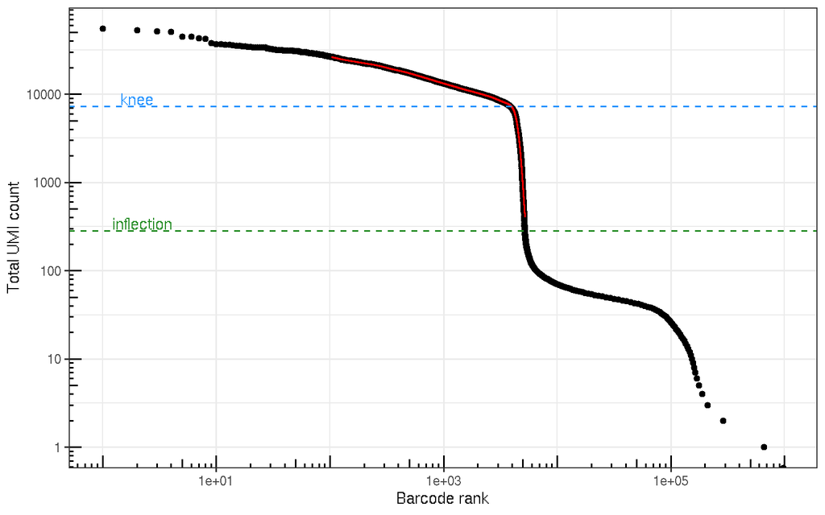

```r
scae
```

```
## class: SingleCellAlleleExperiment
## dim: 62762 5199
## metadata(0):
## assays(2): counts logcounts
## rownames(62762): ENSG00000279928.2 ENSG00000228037.1 ... HLA_class_I
##   HLA_class_II
## rowData names(4): Ensembl_ID Symbol NI_I Quant_type
## colnames(5199): AAACCCAAGCGTATGG AAACCCAGTCCTACAA ... TTTGTTGTCCTTGGAA
##   TTTGTTGTCGCACGAC
## colData names(3): Sample Barcode sizeFactor
## reducedDimNames(0):
## mainExpName: NULL
## altExpNames(0):
```

# 1 Downstream analysis

In the following sections, main steps for dimensional reduction are performed, offering insights into the different data layers of the SCAE object as well giving an idea on how to perform immune gene expression analysis.

## 1.1 Subsetting the different layers

The non-imune genes are combined with each of the integrated immune gene allele-aware layers to determine three different subsets.

### 1.1.1 Non-immune genes + alleles

```r
scae_nonimmune__allels_subset <- scae[c(rownames(scae_subset(scae, "nonimmune")), rownames(scae_subset(scae, "alleles"))), ]

scae_nonimmune__allels_subset
```

```
## class: SingleCellAlleleExperiment
## dim: 62756 5199
## metadata(0):
## assays(2): counts logcounts
## rownames(62756): ENSG00000279928.2 ENSG00000228037.1 ...
##   DPB1*04:01:01:01 DPB1*15:01
## rowData names(4): Ensembl_ID Symbol NI_I Quant_type
## colnames(5199): AAACCCAAGCGTATGG AAACCCAGTCCTACAA ... TTTGTTGTCCTTGGAA
##   TTTGTTGTCGCACGAC
## colData names(3): Sample Barcode sizeFactor
## reducedDimNames(0):
## mainExpName: NULL
## altExpNames(0):
```

### 1.1.2 Non-immune genes + immune genes

```r
scae_nonimmune__immune <- scae[c(rownames(scae_subset(scae, "nonimmune")), rownames(scae_subset(scae, "immune_genes"))), ]

scae_nonimmune__immune
```

```
## class: SingleCellAlleleExperiment
## dim: 62750 5199
## metadata(0):
## assays(2): counts logcounts
## rownames(62750): ENSG00000279928.2 ENSG00000228037.1 ... HLA-C HLA-DRB1
## rowData names(4): Ensembl_ID Symbol NI_I Quant_type
## colnames(5199): AAACCCAAGCGTATGG AAACCCAGTCCTACAA ... TTTGTTGTCCTTGGAA
##   TTTGTTGTCGCACGAC
## colData names(3): Sample Barcode sizeFactor
## reducedDimNames(0):
## mainExpName: NULL
## altExpNames(0):
```

### 1.1.3 Non-immune genes + functional class

```r
scae_nonimmune__functional <- scae[c(rownames(scae_subset(scae, "nonimmune")), rownames(scae_subset(scae, "functional_groups"))), ]

scae_nonimmune__functional
```

```
## class: SingleCellAlleleExperiment
## dim: 62748 5199
## metadata(0):
## assays(2): counts logcounts
## rownames(62748): ENSG00000279928.2 ENSG00000228037.1 ... HLA_class_I
##   HLA_class_II
## rowData names(4): Ensembl_ID Symbol NI_I Quant_type
## colnames(5199): AAACCCAAGCGTATGG AAACCCAGTCCTACAA ... TTTGTTGTCCTTGGAA
##   TTTGTTGTCGCACGAC
## colData names(3): Sample Barcode sizeFactor
## reducedDimNames(0):
## mainExpName: NULL
## altExpNames(0):
```

## 1.2 Dimensional Reduction

### 1.2.1 Model variance and HVGs for all data layers

```r
df_ni_a <- modelGeneVar(scae_nonimmune__allels_subset)
top_ni_a <- getTopHVGs(df_ni_a, prop = 0.1)
```

```r
df_ni_g <- modelGeneVar(scae_nonimmune__immune)
top_ni_g <- getTopHVGs(df_ni_g, prop = 0.1)
```

```r
df_ni_f <- modelGeneVar(scae_nonimmune__functional)
top_ni_f <- getTopHVGs(df_ni_f, prop = 0.1)
```

### 1.2.2 PCA

Compute PCA for each layer and store the results in the object. Its Important to make unique identifiers for each layer/run or the results will be overwritten and just saved as `PCA`. Here, the `runPCA` functions from the *scater* package is used.

```r
set.seed(18)
scae <- runPCA(scae, ncomponents = 10, subset_row = top_ni_a, exprs_values = "logcounts", name = "PCA_a")
scae <- runPCA(scae, ncomponents = 10, subset_row = top_ni_g, exprs_values = "logcounts", name = "PCA_g")
scae <- runPCA(scae, ncomponents = 10, subset_row = top_ni_f, exprs_values = "logcounts", name = "PCA_f")
```

```r
reducedDimNames(scae)
```

```
## [1] "PCA_a" "PCA_g" "PCA_f"
```

### 1.2.3 t-SNE

The same goes for running t-SNE with the `runTSNE` function from the *scater* package. Unique identifiers are stated here for each layer as well.

```r
set.seed(18)
scae <- runTSNE(scae, dimred= "PCA_a",  name = "TSNE_a")
set.seed(18)
scae <- runTSNE(scae, dimred= "PCA_g",  name = "TSNE_g")
set.seed(18)
scae <- runTSNE(scae, dimred= "PCA_f",  name = "TSNE_f")
```

List of results from the performed reduced dimension analysis.

```r
reducedDimNames(scae)
```

```
## [1] "PCA_a"  "PCA_g"  "PCA_f"  "TSNE_a" "TSNE_g" "TSNE_f"
```

```r
head(reducedDims(scae)$TSNE_a)
```

```
##                        [,1]        [,2]
## AAACCCAAGCGTATGG -23.132909   5.6698747
## AAACCCAGTCCTACAA -32.483633  -1.0338931
## AAACCCATCACCTCAC  -9.075365  -7.3143041
## AAACGCTAGGGCATGT   2.589943 -32.8839710
## AAACGCTGTAGGTACG  34.391252   2.9287145
## AAACGCTGTGTCCGGT -30.876738   0.3091164
```

### 1.2.4 HLA-A immune gene and alleles

[figure not shown]

```r
which_tsne <- "TSNE_a"

#EGA_hla_a_alleles
tsne_g_a  <- plotReducedDim(scae, dimred = which_tsne, colour_by = "HLA-A") + ggtitle("HLA-A gene")
tsne_g_a
```

[figure not shown]

```r
tsne_g_a1 <- plotReducedDim(scae, dimred = which_tsne, colour_by = "A*02:01:01:01") + ggtitle("Allele A*02:01:01:01")
tsne_g_a1
```

[figure not shown]

```r
tsne_g_a2 <- plotReducedDim(scae, dimred = which_tsne, colour_by = "A*29:02:01:01") + ggtitle("Allele A*29:01:01:01")

p2 <- tsne_g_a + tsne_g_a1 + tsne_g_a2

p2
```

# 2 Additional

As the SCAE object is extending the SCE object, it is also compatible with the *iSEE* package for interactive data exploration.

```
## R Under development (unstable) (2024-02-26 r85990)
## Platform: x86_64-pc-linux-gnu
## Running under: Ubuntu 22.04.3 LTS
##
## Matrix products: default
## BLAS:   /usr/lib/x86_64-linux-gnu/blas/libblas.so.3.10.0
## LAPACK: /usr/lib/x86_64-linux-gnu/lapack/liblapack.so.3.10.0
##
## locale:
##  [1] LC_CTYPE=en_US.UTF-8       LC_NUMERIC=C
##  [3] LC_TIME=de_DE.UTF-8        LC_COLLATE=en_US.UTF-8
##  [5] LC_MONETARY=de_DE.UTF-8    LC_MESSAGES=en_US.UTF-8
##  [7] LC_PAPER=de_DE.UTF-8       LC_NAME=C
##  [9] LC_ADDRESS=C               LC_TELEPHONE=C
## [11] LC_MEASUREMENT=de_DE.UTF-8 LC_IDENTIFICATION=C
```

[output cut: 77 more lines]